# QMS517 short report: Spatializing fishing effort predictions based on Global Fishing Watch observed data

Gage Clawson

2024-07-04

## Introduction

Marine fisheries deliver a wide range of benefits to society as they contribute to food security and support livelihoods. Understanding how fisheries evolved in space and time is crucial to project their future directions and to plan management actions that will ensure long-term socio-ecological sustainability of fishing practices. Global, spatially explicit fishing effort estimates covering 1950-2017 are available (Rousseau et al., 2024), and they are currently being used in research for risk assessment, management, and modelling. For example, the development of new stock assessment methodologies to support the transition towards climate-resilient fishing at FAO heavily relies on the use of these fishing effort data, particularly for data-poor countries where detailed information on fish stocks and fisheries lacks. In addition, such data inform marine ecosystem models contributing to the Fisheries and Marine Ecosystem Model Intercomparison Project (FishMIP) which aims at projecting ocean biomass and fisheries catches under different climate and socio-economic scenarios to inform policy (www.fishmip.org). However, the most comprehensive current global fishing effort database relies on important assumptions for its spatial allocation model which do not explicity reflect observed fishing patterns (Rousseau et al., 2024).

Additional sources of fishing effort data are available, including the Global Fishing Watch data (GFW; https://globalfishingwatch.org/). These data come with important constraints as they cover a limited time span, are patchy in space, and require intensive wrangling to be converted into useful fishing effort estimates. GFW data is particularly limited in that not all vessels are required to use automatic identification systems (AIS), which allow for monitoring a vessel’s location and activity. In particular, these technologies are most commonly applied in industrial fleets (Kroodsma et al., 2018). To illustrate these limitations, Paolo et al. (2024) compared GFW data to satellite imagery and found that approximately 75% of the world’s industrial fishing vessels are not publicly tracked. Nevertheless, these data can be used to inform and improve currently used estimates of fishing effort. Specifically, GFW data, coupled with statistical approaches for data mapping and prediction provide opportunities to update the industrial fishing effort mapping used in Rousseau et al. 2024, and thus to improve estimates of global geographical patterns and their evolution in time. Here, we focus on exploring modelling methods to gap fill the spatial distribution of fishing effort collected by GFW, with the long-term aim to develop country-specific rules for the spatial distribution of fishing effort.

## Methodology

We focus on Iceland, which Paolo et al. (2024) estimates to be the country with the most comprehensively tracked industrial fishing fleet (~12% of the fleet is untracked by AIS). We begin by reading in gridded data (resampled to 0.1 degree resolution) for depth, distance to shore, distance to port, sea surface temperature, chlorophyll-a, and hours of fishing effort. We subset this data for data year 2020 where appropriate, and crop and mask each raster to Iceland’s exclusive economic zone (EEZ).

First we look at a correlation chart of variables to determine which explanatory variables we can remove from our analysis. We find that distance to shore, distance to port, and depth are all highly correlated variables, and remove distance to port and shore. We acknowledge that there are likely many other factors at play when observing fishing effort (vessel length, gear type, etc.), however for this initial analysis we treat fishing hours as a lump sum in each cell. Following this we fit a number of models to assess fishing effort predictions in Iceland, including GLM, log-normal, poisson, negative binomial, random forest, and GAM models.

```r
## read in reprojected data (completed in a prior script for raw data processing)

depth <- rast(file.path(rdsi_dir, "prep/random_forest/bathymetry_0.1_res.tif"))

dts <- rast(
  file.path(rdsi_raw_dir,
            "global_fishing_watch/distance_from_shore/distance-from-shore_0.1.tif"))

dtp <- rast(
  file.path(rdsi_raw_dir,
            "global_fishing_watch/distance_from_port/distance-from-port-v1_0.1.tif"))

sst <- rast(file.path(rdsi_raw_dir, "noaa/sst/resample_0.1/sst_2020_0.1.tif"))

chla <- rast(file.path(rdsi_dir, "prep/random_forest/chla_2020_0.1.tif"))

effort_subset <- read.csv(
  file.path(rdsi_dir, "prep/random_forest/effort_2020_vut_arg_isl.csv")) %>%
  rename(x = cell_ll_lon, y = cell_ll_lat)

eez_rast <- rast(here("int/eez_raster.tif"))

eez_rast_df <- fread(here("int/eez_raster_df.csv"))

rgn_keys <- read.csv(here("raw/ohi_region_key.csv"))

eez_isl_df <- eez_rast_df %>%
  filter(rgn_id == 143) %>% # filter for iceland EEZ
  dplyr::select(x, y) %>%
  mutate(eez = 1)

# now get EEZ rast we can crop and mask data with
eez_isl_rast <- rast(eez_isl_df, crs = crs(eez_rast), type = "xyz")

## Now crop and mask global data for Iceland's EEZ
# depth
depth_isl <- crop(depth, eez_isl_rast) %>% # crop to correct region
  project(., eez_isl_rast) %>% # make sure extents match
  mask(., eez_isl_rast) %>%  # now mask out any areas not in EEZ
  rename(depth = bathymetry)

## distance to short
dts_isl <- crop(dts, eez_isl_rast) %>% # crop to correct region
  project(., eez_isl_rast) %>% # make sure extents match
  mask(., eez_isl_rast) # now mask out any areas not in EEZ

# distance to port
dtp_isl <- crop(dtp, eez_isl_rast) %>% # crop to correct region
  project(., eez_isl_rast) %>% # make sure extents match
  mask(., eez_isl_rast) # now mask out any areas not in EEZ

# sst
sst_isl <- crop(sst, eez_isl_rast) %>% # crop to correct region
  project(., eez_isl_rast) %>% # make sure extents match
  mask(., eez_isl_rast) # now mask out any areas not in EEZ

chl_isl <- crop(chla, eez_isl_rast) %>% # crop to correct region
  project(., eez_isl_rast) %>% # make sure extents match
  mask(., eez_isl_rast) %>% # now mask out any areas not in EEZ
  rename(chl = mean)


# effort hours
effort_isl <- effort_subset %>%
  group_by(x, y) %>%
  summarise(fishing_hours = sum(fishing_hours, na.rm = TRUE)) %>%
  ungroup() %>%
  rast(., type = "xyz", crs = crs(eez_isl_rast)) %>%
  crop(., eez_isl_rast) %>%
  project(., eez_isl_rast) %>%
  tidyterra::mutate(fishing_hours = ifelse(is.na(fishing_hours), 0, fishing_hours)) %>%
  mask(., eez_isl_rast) # ok so as.data.frame removes NAs?


# now stack all rasters

all_rasts <- c(effort_isl, dtp_isl, dts_isl, depth_isl, sst_isl, chl_isl) %>%
  as.data.frame(., xy = TRUE, na.rm = NA) %>%
  mutate(fis_pres = as.factor(ifelse(fishing_hours > 0, 1, 0))) %>%
  #dplyr::select(-fishing_hours) %>%
  filter(!is.na(depth),
         !is.na(mean),
         !is.na(chl)) %>% # need to filter out NAs for RF to work
  rename(dtp = 4, dts = 5, sst = mean)

all_env_stack <- c(dtp_isl, dts_isl, depth_isl, sst_isl, chl_isl) %>%
    rename(dtp = 1, dts = 2, sst = mean)
```

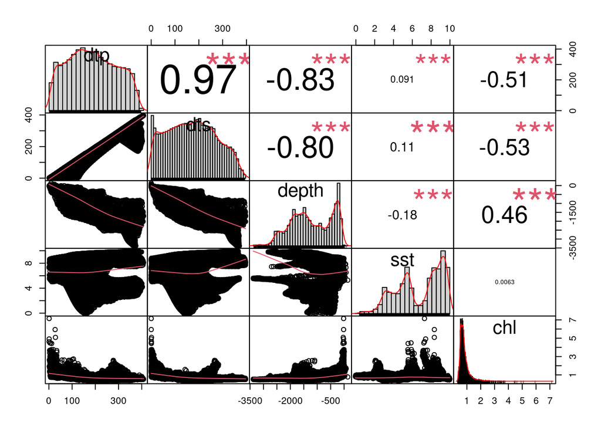

```r
## first lets look at correlations to see if we should remove any variables
chart.Correlation(all_rasts[,4:8])
```

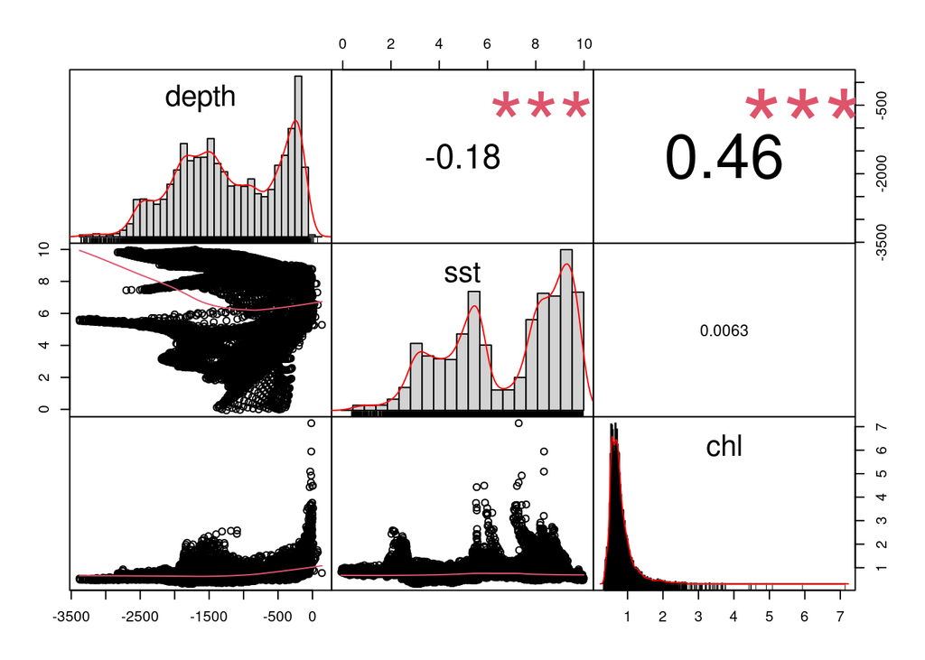

```r
## dts and dtp are really highly correlated.. makes a lot of sense - will want to remove one of those. My guess is distance to port is more important for Argentina, considering they have a lot of industrial fishing
all_rasts_2 <- all_rasts %>% dplyr::select(-dts)

chart.Correlation(all_rasts_2[,5:7]) # looks ok now
```

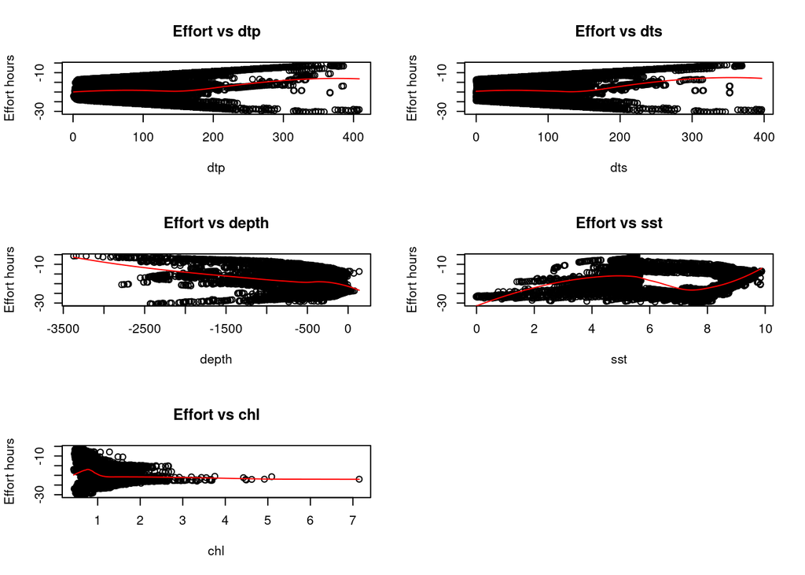

```r
## check if any variables need polynomials
all_rasts <- all_rasts %>%
  filter(fishing_hours > 0)

## lets check the hours of effort against predictor variables
par(mfrow=c(3,2))
for(i in 4:8){
  plot(all_rasts[,1]~all_rasts[,i], ylab="Effort hours", xlab=names(all_rasts)[i], main=paste0("Effort vs ",names(all_rasts)[i]))
  l <- loess(all_rasts[,1]~all_rasts[,i])
  j <- order(all_rasts[,i]) ## values need to be ordered for the red line to run along and not zigzag
  lines(all_rasts[j,i],l$fitted[j], col="red")
}

## based on this, we will fit SST with a polynomial
```

```r
all_rasts$fishing_hours <- ceiling(all_rasts$fishing_hours)

##
effort.formula <- formula("fishing_hours ~ depth+sst+chl+I(sst^2)")
## we also setup the formula for the lognormal model, which uses the log-transformed response:
effort.formula.ln <- formula("log(fishing_hours) ~ depth+sst+chl+I(sst^2)")

## GLMs

## fitting the model and stepwise dropping variables using stepAIC
fit.n <- stepAIC(glm(effort.formula, data=all_rasts,
                     family=gaussian(link="identity")), trace=FALSE)
## check the summary and diagnostics
summary(fit.n)
```

```
##
## Call:
## glm(formula = fishing_hours ~ depth + sst + chl + I(sst^2), family = gaussian(link = "identity"),
##     data = all_rasts)
##
## Deviance Residuals:
##     Min       1Q   Median       3Q      Max
## -653.55   -63.20   -28.59    24.62  2024.70
##
## Coefficients:
##               Estimate Std. Error t value Pr(>|t|)
## (Intercept) -86.845122  15.648895  -5.550 2.98e-08 ***
## depth         0.053140   0.003492  15.217  < 2e-16 ***
## sst          39.770699   4.794373   8.295  < 2e-16 ***
## chl          90.399407   4.561383  19.818  < 2e-16 ***
## I(sst^2)     -3.155503   0.386519  -8.164 3.90e-16 ***
## ---
## Signif. codes:  0 '***' 0.001 '**' 0.01 '*' 0.05 '.' 0.1 ' ' 1
##
## (Dispersion parameter for gaussian family taken to be 18508.85)
##
##     Null deviance: 138571608  on 6134  degrees of freedom
## Residual deviance: 113459244  on 6130  degrees of freedom
## AIC: 77700
##
## Number of Fisher Scoring iterations: 2
```

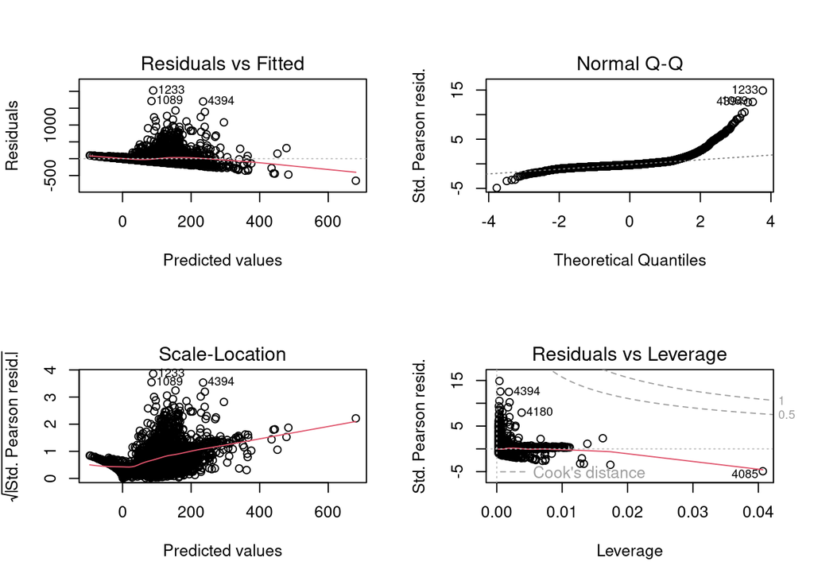

```r
par(mfrow=c(2,2))
plot(fit.n)
```

```r
## AIC is realllllly big. Really large range of residuals, suggesting a lot of variability.
# residual deviance has lots of unexplained variance
# Not a great fit.

## lognormal
fit.ln <- stepAIC(glm("log(ceiling(fishing_hours)) ~ depth+sst+chl+I(sst^2)",
                      data=all_rasts, family=gaussian(link="identity")),
                  trace=FALSE)
summary(fit.ln)
```

```
##
## Call:
## glm(formula = log(ceiling(fishing_hours)) ~ depth + sst + chl +
##     I(sst^2), family = gaussian(link = "identity"), data = all_rasts)
##
## Deviance Residuals:
##     Min       1Q   Median       3Q      Max
## -7.4044  -0.9915   0.1312   1.0554   4.3309
##
## Coefficients:
##              Estimate Std. Error t value Pr(>|t|)
## (Intercept)  0.916996   0.165822    5.53 3.33e-08 ***
## depth        0.001755   0.000037   47.44  < 2e-16 ***
## sst          0.767881   0.050803   15.12  < 2e-16 ***
## chl          0.912231   0.048334   18.87  < 2e-16 ***
## I(sst^2)    -0.061727   0.004096  -15.07  < 2e-16 ***
## ---
## Signif. codes:  0 '***' 0.001 '**' 0.01 '*' 0.05 '.' 0.1 ' ' 1
##
## (Dispersion parameter for gaussian family taken to be 2.078247)
##
##     Null deviance: 24102  on 6134  degrees of freedom
## Residual deviance: 12740  on 6130  degrees of freedom
## AIC: 21905
##
## Number of Fisher Scoring iterations: 2
```

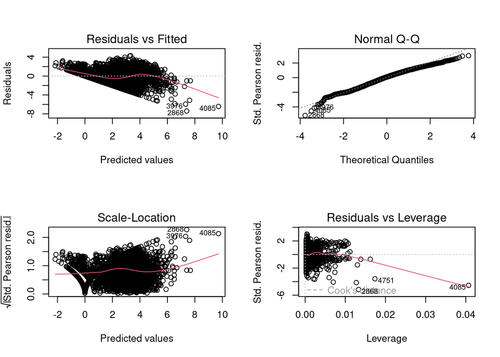

```r
par(mfrow=c(2,2))
plot(fit.ln)
```

```r
mu <- fitted(fit.ln)
sigma <- summary(fit.ln)$df.residual/nrow(all_rasts)*sqrt(summary(fit.ln)$dispersion)
-2*sum(log(dlnorm(all_rasts$fishing_hours,mu,sigma)))+2*(length(coef(fit.ln))+1)
```

```
## [1] 57602.44
```

```r
## this one is a bit better, but still not great.
# AIC is lower and plots look not as skewed
# residuals are much smaller, indicating a better fit


## poisson

fit.p <- stepAIC(glm(effort.formula, data=all_rasts, family=poisson()), trace=FALSE)
summary(fit.p)
```

```
##
## Call:
## glm(formula = fishing_hours ~ depth + sst + chl + I(sst^2), family = poisson(),
##     data = all_rasts)
##
## Deviance Residuals:
##     Min       1Q   Median       3Q      Max
## -38.611   -7.638   -2.844    1.577   99.817
##
## Coefficients:
##               Estimate Std. Error z value Pr(>|z|)
## (Intercept)  4.008e+00  2.612e-02  153.47   <2e-16 ***
## depth        2.855e-03  9.296e-06  307.14   <2e-16 ***
## sst          3.539e-01  7.773e-03   45.52   <2e-16 ***
## chl          2.316e-01  2.490e-03   93.01   <2e-16 ***
## I(sst^2)    -2.689e-02  5.931e-04  -45.34   <2e-16 ***
## ---
## Signif. codes:  0 '***' 0.001 '**' 0.01 '*' 0.05 '.' 0.1 ' ' 1
##
## (Dispersion parameter for poisson family taken to be 1)
##
##     Null deviance: 988872  on 6134  degrees of freedom
## Residual deviance: 596793  on 6130  degrees of freedom
## AIC: 626177
##
## Number of Fisher Scoring iterations: 6
```

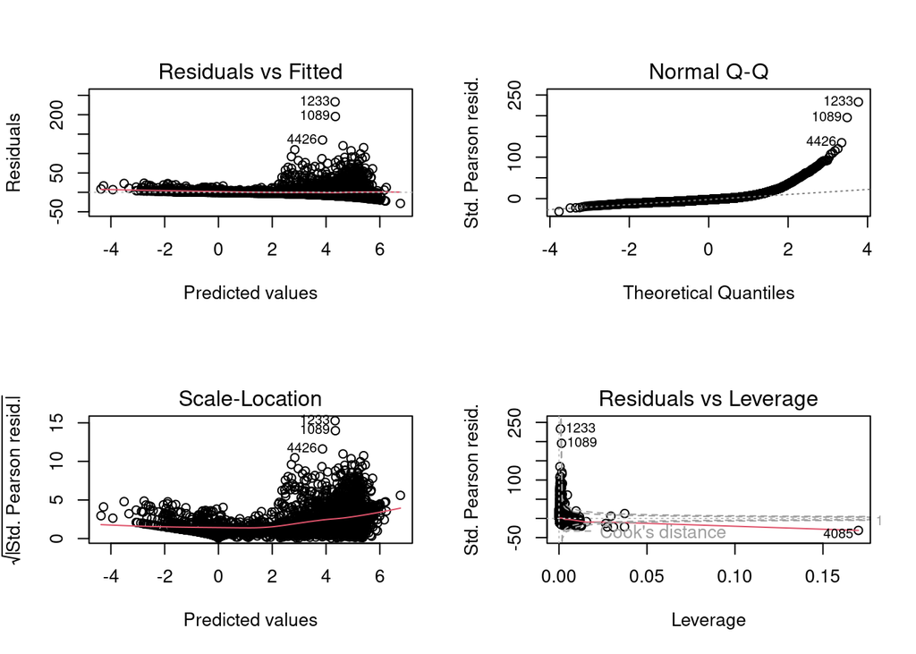

```r
par(mfrow=c(2,2))
plot(fit.p)
```

```r
## Really wide range of residuals. Not as bad as GLM though.
## AIC is huge, indicating worse fit than GLM.
## plots look really bad.


## Negative binomial

fit.nb <- stepAIC(glm.nb(effort.formula, data=all_rasts), trace=FALSE)
summary(fit.nb)
```

```
##
## Call:
## glm.nb(formula = fishing_hours ~ depth + sst + chl + I(sst^2),
##     data = all_rasts, init.theta = 0.7168794565, link = log)
##
## Deviance Residuals:
##     Min       1Q   Median       3Q      Max
## -3.0915  -1.1361  -0.5101   0.1812   6.2808
##
## Coefficients:
##               Estimate Std. Error z value Pr(>|z|)
## (Intercept)  2.194e+00  1.433e-01   15.31   <2e-16 ***
## depth        1.936e-03  3.477e-05   55.68   <2e-16 ***
## sst          6.615e-01  4.384e-02   15.09   <2e-16 ***
## chl          8.145e-01  4.007e-02   20.33   <2e-16 ***
## I(sst^2)    -5.183e-02  3.546e-03  -14.62   <2e-16 ***
## ---
## Signif. codes:  0 '***' 0.001 '**' 0.01 '*' 0.05 '.' 0.1 ' ' 1
##
## (Dispersion parameter for Negative Binomial(0.7169) family taken to be 1)
##
##     Null deviance: 12493.1  on 6134  degrees of freedom
## Residual deviance:  7054.1  on 6130  degrees of freedom
## AIC: 58406
##
## Number of Fisher Scoring iterations: 1
##
##
##               Theta:  0.7169
##           Std. Err.:  0.0118
##
##  2 x log-likelihood:  -58393.6060
```

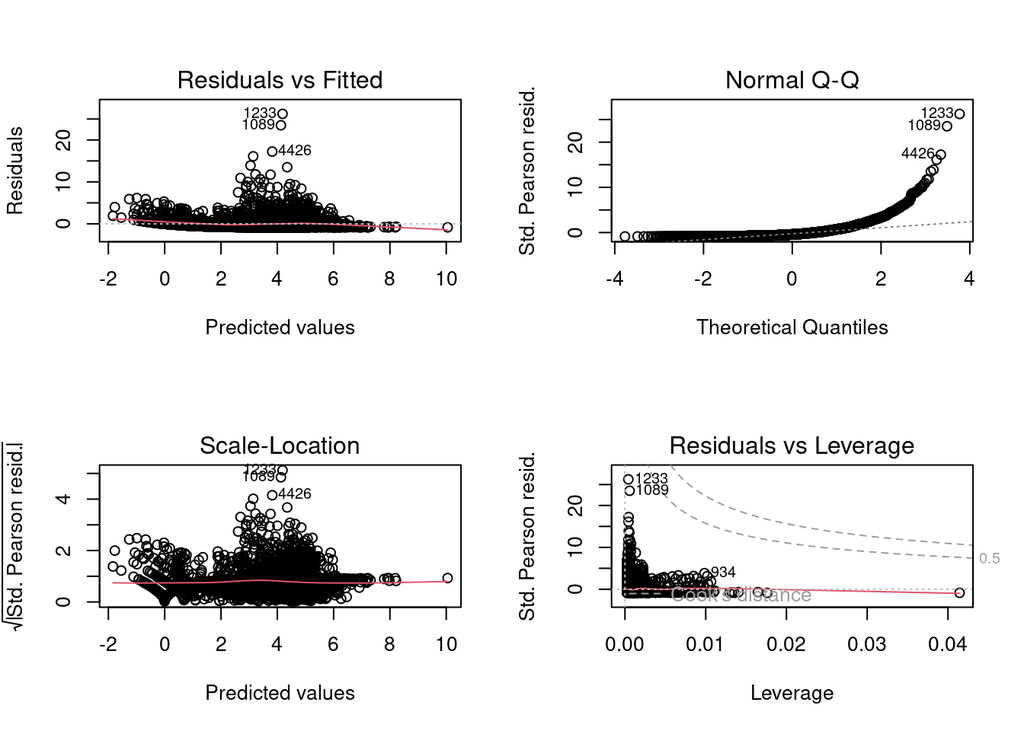

```r
par(mfrow=c(2,2))
plot(fit.nb)
```

```r
## Residuals look ok, not as big as possion or GLM.
## data has overdispersion
## AIC lower than possion but higher than log-normal
## so far negative binomial or log-normal are the winners

fit.rf <- randomForest(effort.formula, data=all_rasts, ntree=500)
fit.rf
```

```
##
## Call:
##  randomForest(formula = effort.formula, data = all_rasts, ntree = 500)
##                Type of random forest: regression
##                      Number of trees: 500
## No. of variables tried at each split: 1
##
##           Mean of squared residuals: 12523.7
##                     % Var explained: 44.55
```

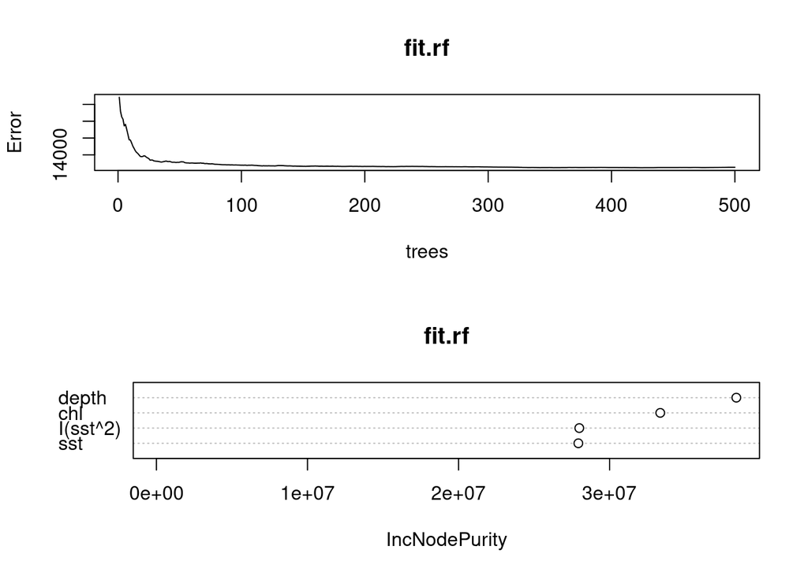

```r
par(mfrow=c(2,1))
plot(fit.rf) # depth most important
varImpPlot(fit.rf)
```

```r
## Pretty quickly reduces error
## Explains ~45% of variance, which is pretty good.


## GAMs - add smooth spatial term

fit.gam <- gam(ceiling(fishing_hours) ~ depth+sst+I(sst^2)+chl+ s(x,y),
               data=all_rasts, family=nb())
summary(fit.gam)
```

```
##
## Family: Negative Binomial(0.918)
## Link function: log
##
## Formula:
## ceiling(fishing_hours) ~ depth + sst + I(sst^2) + chl + s(x,
##     y)
##
## Parametric coefficients:
##               Estimate Std. Error z value Pr(>|z|)
## (Intercept)  1.672e+00  2.345e-01   7.129 1.01e-12 ***
## depth        2.165e-03  7.193e-05  30.093  < 2e-16 ***
## sst          1.475e+00  7.047e-02  20.923  < 2e-16 ***
## I(sst^2)    -1.396e-01  7.405e-03 -18.857  < 2e-16 ***
## chl         -1.617e-02  5.209e-02  -0.310    0.756
## ---
## Signif. codes:  0 '***' 0.001 '**' 0.01 '*' 0.05 '.' 0.1 ' ' 1
##
## Approximate significance of smooth terms:
##          edf Ref.df Chi.sq p-value
## s(x,y) 28.29  28.97   2513  <2e-16 ***
## ---
## Signif. codes:  0 '***' 0.001 '**' 0.01 '*' 0.05 '.' 0.1 ' ' 1
##
## R-sq.(adj) =  0.228   Deviance explained = 57.2%
## -REML =  28360  Scale est. = 1         n = 6135
```

```r
## depth highly significant (matches to RF)
## chla not significant
## Strong spatial pattern in the data for the smooth terms
## ~57% deviance explained
## Because we include spatial structure here, we get a more nuanced fit.


fit.gam2 <- gam(ceiling(fishing_hours) ~ s(depth)+s(sst)+s(chl)+s(x, y),
                data=all_rasts, family=nb())
summary(fit.gam2)
```

```
##
## Family: Negative Binomial(0.981)
## Link function: log
##
## Formula:
## ceiling(fishing_hours) ~ s(depth) + s(sst) + s(chl) + s(x, y)
##
## Parametric coefficients:
##             Estimate Std. Error z value Pr(>|z|)
## (Intercept)   3.5069     0.0136   257.9   <2e-16 ***
## ---
## Signif. codes:  0 '***' 0.001 '**' 0.01 '*' 0.05 '.' 0.1 ' ' 1
##
## Approximate significance of smooth terms:
##             edf Ref.df  Chi.sq p-value
## s(depth)  8.231  8.842  977.41  <2e-16 ***
## s(sst)    7.412  8.393  457.18  <2e-16 ***
## s(chl)    7.136  8.204   76.08  <2e-16 ***
## s(x,y)   28.294 28.942 1981.12  <2e-16 ***
## ---
## Signif. codes:  0 '***' 0.001 '**' 0.01 '*' 0.05 '.' 0.1 ' ' 1
##
## R-sq.(adj) =  0.232   Deviance explained = 60.8%
## -REML =  28108  Scale est. = 1         n = 6135
```

```r
## Slightly improved from previous GAM
## Non-linear relationships between effort and variables
## Seems like this model might be the best fit
```

## Results and Conclusion

These results suggest incorporating complex, non-linear relationships and spatial dependencies is crucial for accurately predicting fishing effort. Regions with similar environmental variability may benefit from applying a similar modeling approach. However, localised environmental conditions and spatial patterns need to be considered to predict fishing effort. There are many other factors at play, including gear types, vessel lengths, and regional-specific capacity derived from wealth of fleets. Fitting models based on these additional considerations will be important for future methodologies.

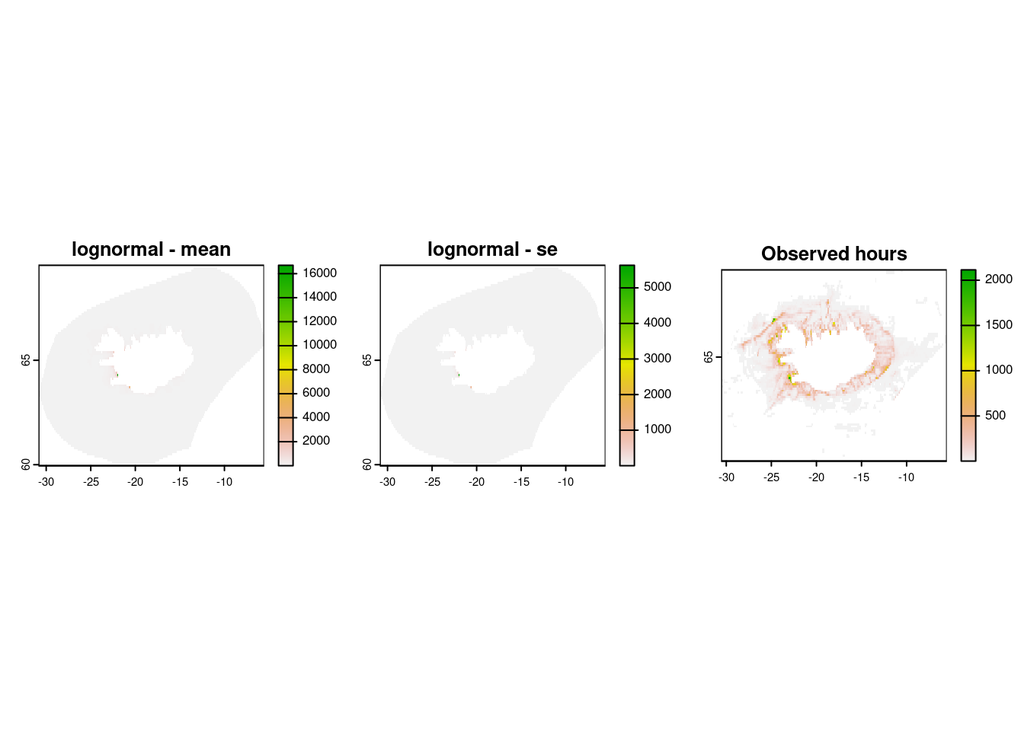

```r
#extract both mean and se of predictions
predfun <- function(model, data) {
  v <- predict(model, data, type="response", se.fit=TRUE)
  cbind(p=as.vector(v$fit), se=as.vector(v$se.fit))
}

## for the lognormal:
predfun.ln <- function(model, data) {
  v <- predict(model, data, type="response", se.fit=TRUE)
  cbind(p=as.vector(exp(v$fit)), se=as.vector(exp(v$fit+v$se.fit)-exp(v$fit)))
}

#for the gams, we need to create a raster of lons and lats to predict on
ra.lon <- raster(all_env_stack$depth)
ra.lon[] <- coordinates(stack(all_env_stack)$depth)[,1]
ra.lat <- raster(all_env_stack$depth)
ra.lat[] <- coordinates(stack(all_env_stack)$depth)[,2]
ra.lon <- rast(ra.lon)
ra.lat <- rast(ra.lat)
all_env_stack$x <- ra.lon
all_env_stack$y <- ra.lat


#generate prediction maps
pred.n <- terra::predict(all_env_stack, fit.n, fun=predfun, index=1:2)
pred.ln <- predict(all_env_stack, fit.ln, fun=predfun.ln, index=1:2)
pred.p <-    predict(all_env_stack, fit.p, fun=predfun, index=1:2)
pred.nb <-   predict(all_env_stack, fit.nb, fun=predfun, index=1:2)
pred.gam <-  predict(all_env_stack, fit.gam, fun=predfun, index=1:2)
pred.gam2 <-  predict(all_env_stack, fit.gam2, fun=predfun, index=1:2)
names(pred.ln) <- names(pred.p) <- names(pred.gam) <- names(pred.gam2) <- c("mean prediction", "std error")

## brt prediction is a bit different here
all_env_stack$depth2 <- all_env_stack$depth^2

## rf prediction
pred.rf <-   predict(all_env_stack, fit.rf, type="response")


fish_eff_rast <- all_rasts %>%
  dplyr::select(x, y, fishing_hours) %>%
  rast(., type = "xyz")

## wont even bother wtih normal, poisson, or negative binomial

## lognormal
par(mfrow=c(1,3))
## mean
plot(pred.ln,1, main="lognormal - mean")
## standard error
plot(pred.ln,2, main="lognormal - se")
plot(fish_eff_rast, main = "Observed hours")
```

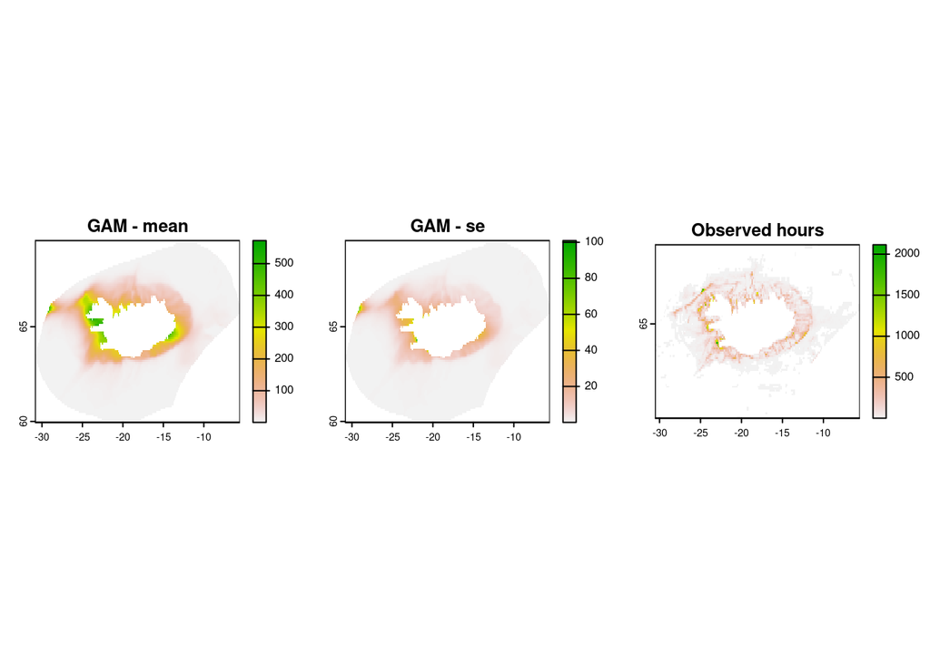

```r
## gam
par(mfrow=c(1,3))
## mean
plot(pred.gam,1, main="GAM - mean")
## standard error
plot(pred.gam,2, main="GAM - se")
plot(fish_eff_rast, main = "Observed hours")
```

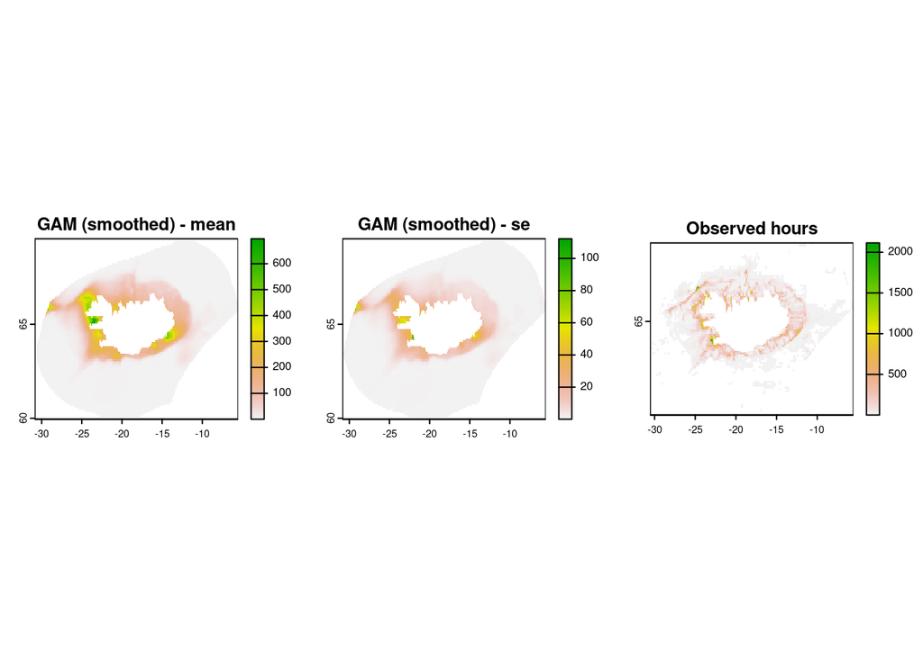

```r
## gam with smoothing
par(mfrow=c(1,3))
## mean
plot(pred.gam2,1, main="GAM (smoothed) - mean")
## standard error
plot(pred.gam2,2, main="GAM (smoothed) - se")
plot(fish_eff_rast, main = "Observed hours")
```

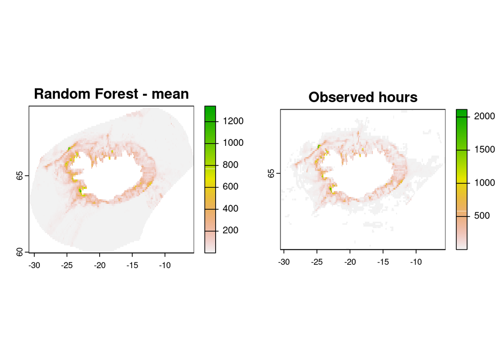

```r
## this seems to match the best


## random forest
par(mfrow=c(1,2))
## mean
plot(pred.rf,1, main="Random Forest - mean")
plot(fish_eff_rast, main = "Observed hours")
```

```r
## random forest looks the best, however does it fit too well??
# It looks remarkably similar to the raw data.
```

## Data sources

### Global Fishing Watch: Apparent Fishing Effort

**Reference**: Global Fishing Watch. [2024]. www.globalfishingwatch.org

**Downloaded**: July 3, 2024

**Description**: Apparent fishing effort within global EEZ’s, labeled by MMSI (vessel ID).

**Native data resolution**: 0.1 degree

**Time range**: 2012 - 2020

**Format**: csv

**Reference**: Global Fishing Watch. [2024]. www.globalfishingwatch.org

**Downloaded**: July 3, 2024

**Description**: This is an ancillary GIS dataset for our fishing work. It provides, at one kilometer resolution, the distance from shore (in kilometers) of every point in the ocean. We use this raster to calculate the distance from shore for every AIS position message in our database.

**Native data resolution**: 1km

**Format**: csv

**Reference**: Global Fishing Watch. [2024]. www.globalfishingwatch.org

**Downloaded**: July 3, 2024

**Description**: This is an ancillary GIS dataset for our fishing work. It provides, at one kilometer resolution, the distance from port of every point in the ocean. We use this raster to calculate the distance from port for every AIS position message in our database.

**Native data resolution**: 1km

**Format**: csv

### Global Fishing Watch: Bathymetry

**Reference**: Global Fishing Watch. [2024]. www.globalfishingwatch.org

**Downloaded**: July 3, 2024

**Description**:This is an ancillary GIS dataset for our fishing work. It contains the bathymetry layer used to assign a depth for every AIS position message in our database. These data are sourced from the General Bathymetric Chart of the Oceans (GEBCO).

**Native data resolution**: 0.1 degree

**Format**: .tif

### NOAA OI SST V2 High Resolution Dataset

**Reference**: NOAA. [2024]. https://psl.noaa.gov/data/gridded/data.noaa.oisst.v2.highres.html

**Downloaded**: July 3, 2024

**Description**: Data ia high resolution of Daily OISST using multi-satellite sensor (AVHRR+VIIRS) data.

**Native data resolution**: 0.25 degree

**Time range**: 1981 - present

**Format**: .nc

### Chlorophyll-a concentration

**Reference**: Yu et al. 2022: https://www.frontiersin.org/journals/marine-science/articles/10.3389/fmars.2023.1051619/full

**Downloaded**: July 3, 2024

**Description**: A new merged dataset of global ocean chlorophyll-a concentration for better trend detection

**Native data resolution**: 4km

**Time range**: 2002-2020

**Format**: .nc

## Literature references

Kroodsma, D.A., Mayorga, J., Hochberg, T., Miller, N.A., Boerder, K., Ferretti, F., Wilson, A., Bergman, B., White, T.D., Block, B.A., Woods, P., Sullivan, B., Costello, C., Worm, B., 2018. Tracking the global footprint of fisheries. Science 359, 904–908. https://doi.org/10.1126/science.aao5646

Paolo, F.S., Kroodsma, D., Raynor, J., Hochberg, T., Davis, P., Cleary, J., Marsaglia, L., Orofino, S., Thomas, C., Halpin, P., 2024. Satellite mapping reveals extensive industrial activity at sea. Nature 625, 85–91. https://doi.org/10.1038/s41586-023-06825-8

Rousseau, Y., Blanchard, J.L., Novaglio, C., Pinnell, K.A., Tittensor, D.P., Watson, R.A., Ye, Y., 2024. A database of mapped global fishing activity 1950–2017. Sci Data 11, 48. https://doi.org/10.1038/s41597-023-02824-6